# Model Gallery

# Load packages required for the gallery

```r
library(mrgsolve)
library(dplyr)
library(ggplot2)
library(magrittr)
library(tidyr)
```

# Simple PK model

About this model specification code

- We set a simulation grid of 0.1 units in `$SET`
- Compartment number (2) and names (`GUT` and `CENT`) are established in `$CMT`
- For dosing purposes, `GUT` is compartment 1 and `CENT` is compartment 2 due to the order of their declaration
- Compartment names and numbers can be checked with `init(mod)`

```r
code <- '
$PARAM CL = 1.3, VC=28, KA=0.6

$SET delta=0.1

$CMT GUT CENT

$ODE
dxdt_GUT = -KA*GUT;
dxdt_CENT = KA*GUT - (CL/VC)*CENT;

$TABLE double CP = CENT/VC;

$CAPTURE CP
'
```

Compile and load

```r
mod <- mread("gallery1", tempdir(),code)
```

```r
mod
```

```
.
.
. -------- mrgsolve model object (unix) --------
.   Project: /private/var/fol...dbsj0x4637ptj4hnd7kg900000gp/T/Rtmp3UFV0A
.   source:        gallery1.cpp
.   shared object: gallery1-so-6eaca557b7
.
.   compile date:
.   Time:          start: 0 end: 24 delta: 0.1
.   >              add: <none>
.   >              tscale: 1
.
.   Compartments:  GUT CENT [2]
.   Parameters:    CL VC KA [3]
.   Omega:         0x0
.   Sigma:         0x0
.
.   Solver:        atol: 1e-08 rtol: 1e-08
.   >              maxsteps: 2000 hmin: 0 hmax: 0
```

## Run with initial value

```r
out <- mod %>% init(GUT=1000) %>% mrgsim(end=72)
```

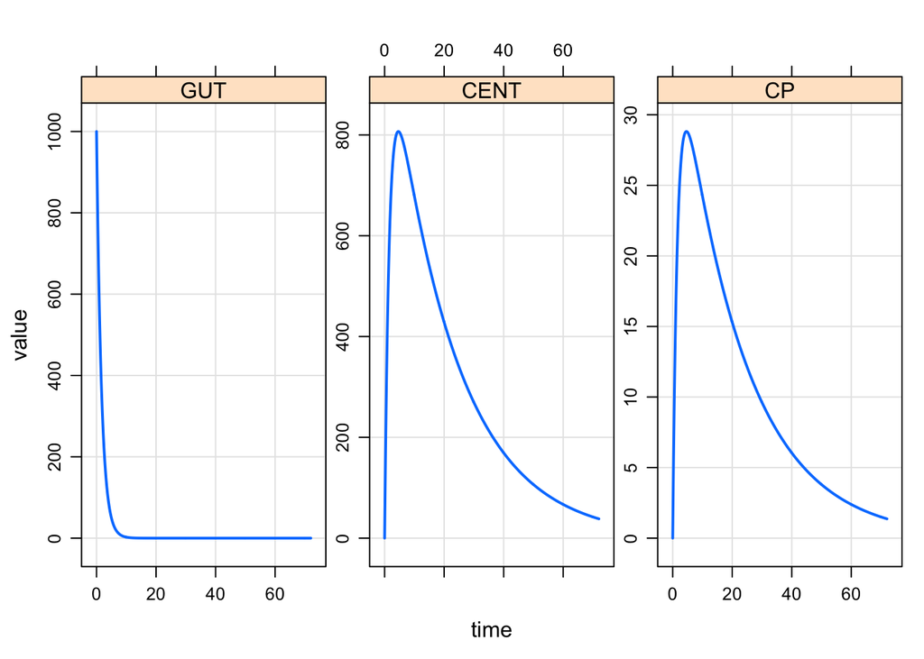

```r
plot(out)
```

```r
out
```

```
. Model:  gallery1.cpp
. Dim:    721 x 5
. Time:   0 to 72
. ID:     1
.      ID time    GUT  CENT     CP
. [1,]  1  0.0 1000.0   0.0  0.000
. [2,]  1  0.1  941.8  58.1  2.075
. [3,]  1  0.2  886.9 112.5  4.019
. [4,]  1  0.3  835.3 163.6  5.841
. [5,]  1  0.4  786.6 211.3  7.547
. [6,]  1  0.5  740.8 256.0  9.145
. [7,]  1  0.6  697.7 297.9 10.639
. [8,]  1  0.7  657.0 337.1 12.038
```

## Run with `events` object

```r
out <- mod %>% ev(amt=1000, ii=12, addl=15) %>% mrgsim(end=336)
```

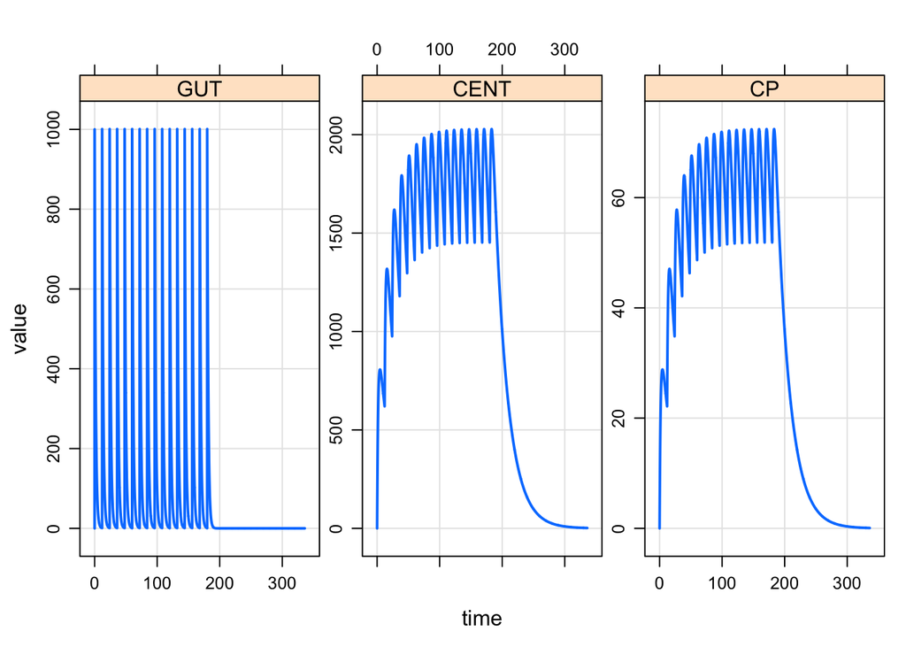

```r
plot(out)
```

The events object was just a simple data set that looks like this

```r
dosing <- events(out)
dosing
```

```
. Events:
.   time cmt  amt ii addl evid
. 1    0   1 1000 12   15    1
```

## Run with data set

Just like the events object, but we can make it more complicated, specify more people, etc…

```r
data <- expand.ev(amt=c(300,1000,3000), ii=12, addl=6) %>% mutate(dose=amt)
data
```

```
.   ID  amt ii addl evid cmt time dose
. 1  1  300 12    6    1   1    0  300
. 2  2 1000 12    6    1   1    0 1000
. 3  3 3000 12    6    1   1    0 3000
```

```r
out <- mod %>% data_set(data) %>% carry.out(dose) %>% Req(CP) %>% mrgsim(end=168)
```

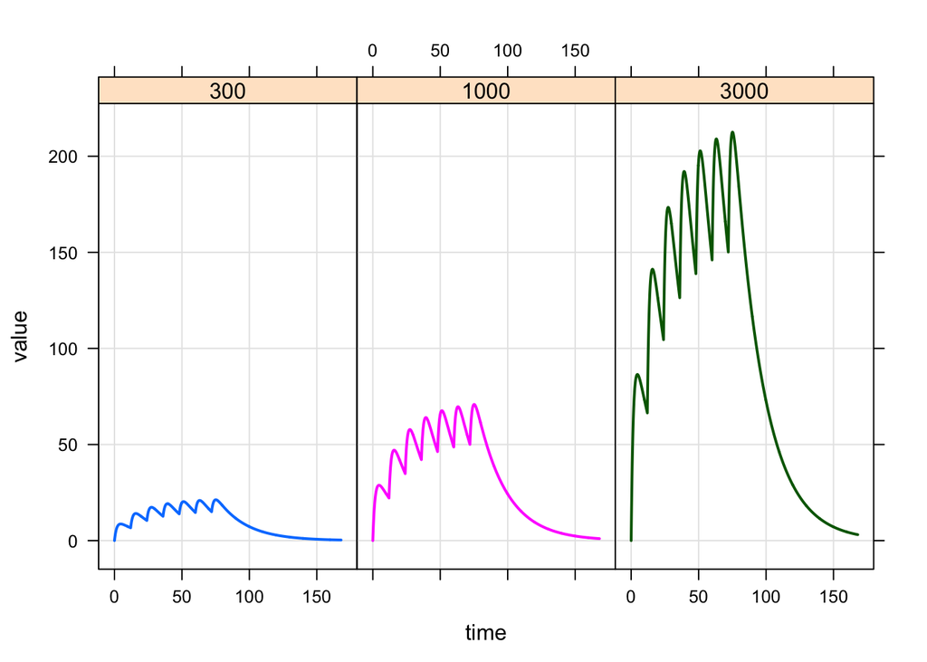

```r
plot(out, CP~time|factor(dose),scales="same")
```

# PK model with different bioavability and dosing lag time

About this model specification code

- Set `F_CENT` and `ALAG_CENT` in `$MAIN`
- Since `F_CENT` is set to `F1` and `ALAG_CENT` is set to `ALG`; since `F1` and `ALG` are named in `$PARAM`, we can update them on the `R` side either through `param` or in an input data set that is also determined on the `R` side of things

```r
code <- '
$PARAM CL = 1.3, VC=28, KA=0.6, ALG=0, F1=1,FORM=1

$SET delta=0.1

$CMT CENT

$MAIN
F_CENT = 1;

// Formulation 2 has lower bioavailability
if(FORM==2) F_CENT = F1;

// Same lag time across formulations
ALAG_CENT = ALG;


$ODE dxdt_CENT = - (CL/VC)*CENT;

$TABLE double CP = CENT/VC;

$CAPTURE CP

'
```

Compile and load

```r
mod <- mread("gallery2", tempdir(), code)
```

Dose into the central compartment. Also, `ALG`, `F1`, and `FORM` are updated via the data set and therefore need to be columns in the data set and listed in `$PARAM`

```r
data <- expand.ev(amt=1000, ALG=seq(0,12,4),FORM=c(1,2)) %>% mutate(F1 = ifelse(FORM==1,1,0.5))

data
```

```
.   ID  amt ALG FORM evid cmt time  F1
. 1  1 1000   0    1    1   1    0 1.0
. 2  2 1000   4    1    1   1    0 1.0
. 3  3 1000   8    1    1   1    0 1.0
. 4  4 1000  12    1    1   1    0 1.0
. 5  5 1000   0    2    1   1    0 0.5
. 6  6 1000   4    2    1   1    0 0.5
. 7  7 1000   8    2    1   1    0 0.5
. 8  8 1000  12    2    1   1    0 0.5
```

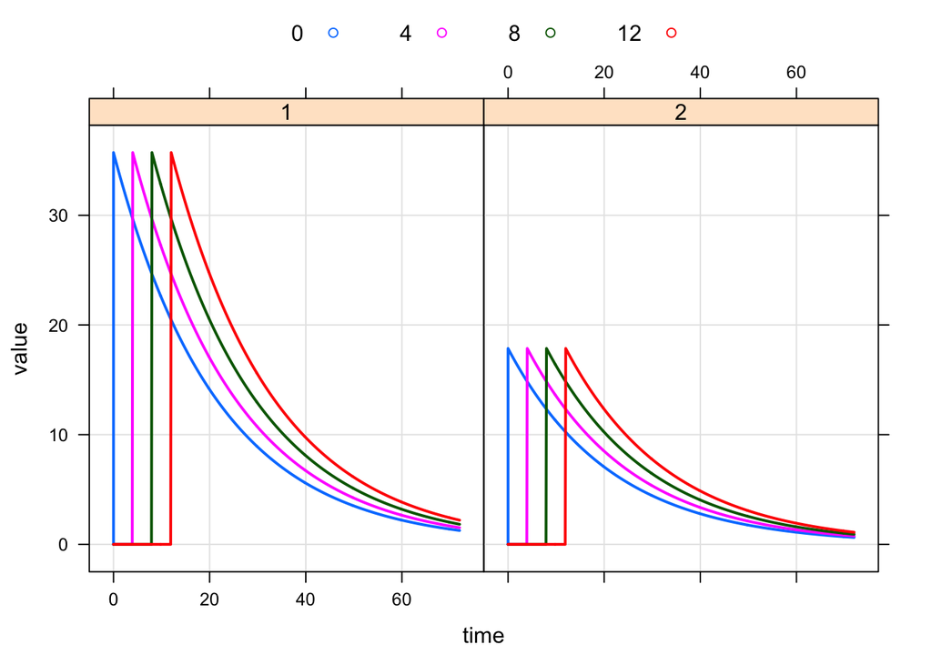

```r
out <- mod %>% data_set(data) %>% carry.out(FORM,ALG) %>% mrgsim(end=72)

plot(out, CP~time|factor(FORM),group=ALG, scales="same", auto.key=list(columns=4))
```

# PK model with residual error

About this model specification code

- `$SIGMA` sets the variance of `EPS(n)`
- Setting `end` to a value less than 0 will signal `mrgsolve` to skip the simulation time grid
- We specify `add` to get a specific set of simulation times (not necessarily evenly spaced)

```r
code <- '
$PARAM CL = 1.3, VC=28, KA=0.6

$GLOBAL #define CP (CENT/VC)

$SIGMA 0.025

$SET end=-1, add=c(0,0.25,0.5,1,2,4,6,8,10,12,16,24,36,48)

$CMT GUT CENT

$ODE
dxdt_GUT = -KA*GUT;
dxdt_CENT = KA*GUT - (CL/VC)*CENT;

$CAPTURE CP DV

$TABLE double DV = CP*exp(EPS(1));
'
```

```r
mod <- mread("ruv", tempdir(), code)
```

```r
set.seed(3203)
out <- mod %>% init(GUT=1000) %>% obsonly %>% mrgsim(Req="CP,DV") %>% as.data.frame
```

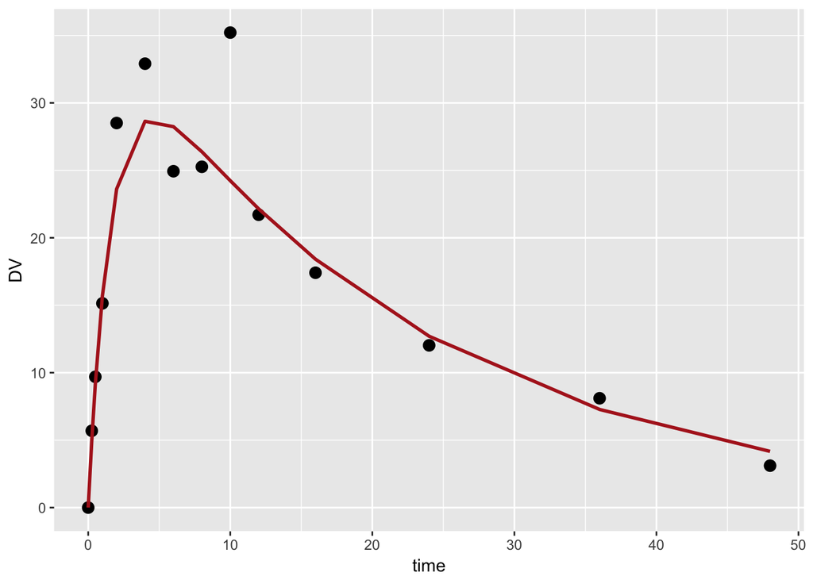

```r
ggplot(data=out, aes(x=time)) + geom_point(aes(y=DV),size=3) + geom_line(aes(y=CP), col="firebrick",lwd=1)
```

# Indirect response model driven by continuous PK

About this model specification code

- `CP` is “defined” in `$GLOBAL`
- `INH` is declared as a double precision variable in `$ODE`
- `INH` will be available globally (`mrgsolve` will declare the variable in `$GLOBAL` for you)
- `INH` can be changed at any time, but `CP` cannot
- Both `CP` and `INH` can be inserted into output in `$TABLE` or `$CAPTURE`

```r
code <- '
$PARAM CL = 5.3, VC=28, KA=0.6, KIN=20, KOUT=0.01, IC50=10

$SET delta=0.1

$CMT GUT CENT RESPONSE

$GLOBAL
#define CP (CENT/VC)

$MAIN
RESPONSE_0 = KIN/KOUT;

$ODE

double INH = CP/(IC50+CP);

dxdt_GUT = -KA*GUT;
dxdt_CENT = KA*GUT - (CL/VC)*CENT;

dxdt_RESPONSE = KIN*(1-INH) - KOUT*RESPONSE;


$CAPTURE CP INH
'
```

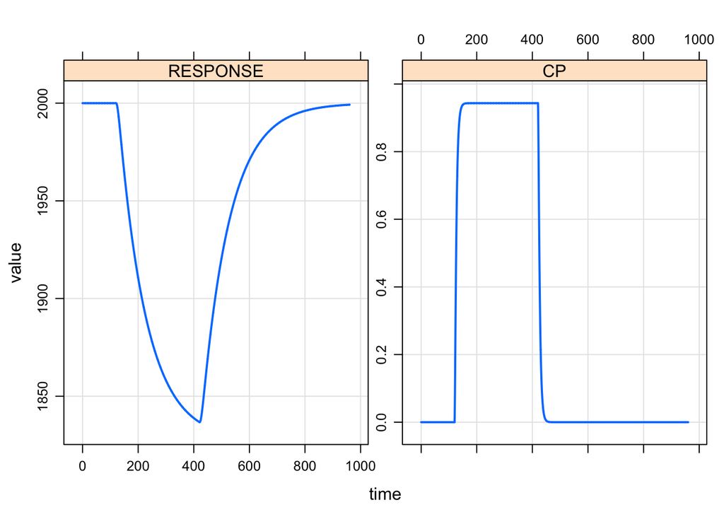

```r
mod <- mread("gallery3", tempdir(), code)

out <- mod %>%
  ev(time=120,amt=1500,rate=5) %>%
  Req(CP,RESPONSE) %>% mrgsim(end=480*2)

plot(out)
```

# Indirect response model driven by metric summarizing exposure

About this model specification code

- Take out the PK model
- `AUC` will drive the PD model
- `AUC` is declared in `$PARAM`; we will manipulate that value (AUC>0 for on treatment, AUC==0 for off treatment) through the input data set

```r
code <- '
$PARAM AUC=0, KIN=100, KOUT=0.2, AUC50=10

$SET delta=0.1

$CMT RESPONSE

$GLOBAL
#define INH (AUC/(AUC50+AUC))

$MAIN
RESPONSE_0 = KIN/KOUT;

$ODE

dxdt_RESPONSE = KIN*(1-INH) - KOUT*RESPONSE;

$CAPTURE AUC
'
```

```r
mod <- mread("gallery5", tempdir(), code)
```

Make a template data set with `evid`=2 and `AUC` to drive the PD model

```r
data <- ev(ID=1,evid=2,AUC=15, ii=48,addl=0,amt=0) %then% ev(ID=1,evid=2,AUC=0,amt=0)

data
```

```
. Events:
.   ID time cmt AUC ii addl amt evid
. 1  1    0   1  15 48    0   0    2
. 2  1   48   1   0  0    0   0    2
```

```r
out <- mod %>% data_set(data) %>% obsonly %>% mrgsim(end=120)
```

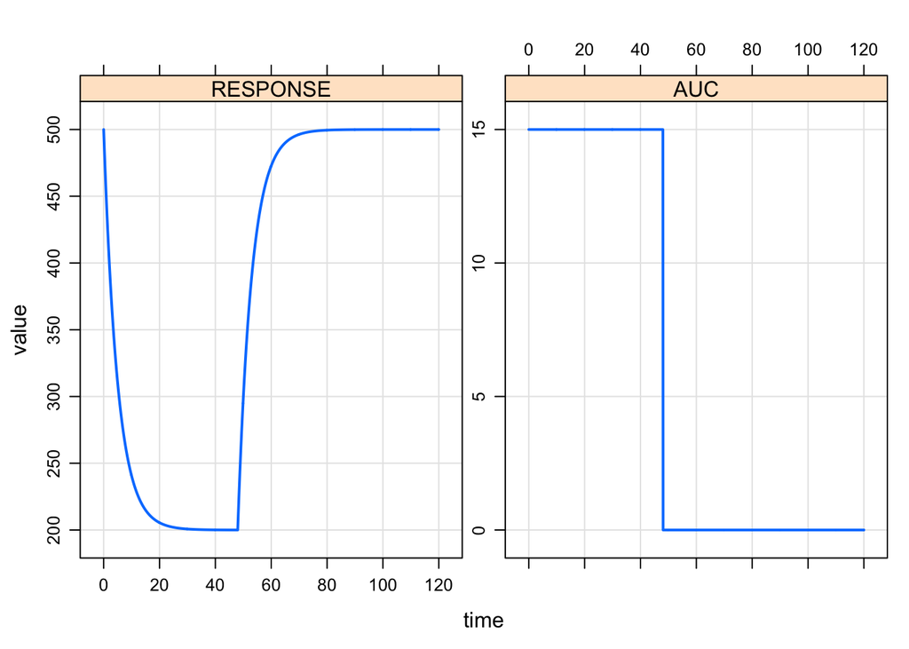

```r
plot(out)
```

# Effect compartment model

About this model specification code

- This code replicates model PD21 in Gabrielsson and Weiner 2007.

```r
code <- '
$PARAM
VC = 2.44, KA = 0.92, K10 = 0.44, K12 = 0.36, K21 = 0.24
E0 = 157, EMAX = 29.95, EC50=4.956, KEO=1.305

$SET delta=0.1, end=36

$CMT GUT CENT PERIPH CE

$ODE
double CP = CENT/VC;

dxdt_GUT = -KA*GUT;
dxdt_CENT = KA*GUT - K10*CENT - K12*CENT + K21*PERIPH;
dxdt_PERIPH = K12*CENT - K21*PERIPH;
dxdt_CE = KEO*(CP-CE);

$TABLE
double EFFECT = E0 - EMAX*CE/(CE+EC50);
CP = CENT/VC;

$CAPTURE EFFECT CP
'
```

```r
mod <- mread("effcmt", tempdir(), code)
```

Simulate a snigle 200 unit dose

```r
out <- mod %>% ev(amt=200) %>% obsonly %>% mrgsim(Req="CP,CE,EFFECT")
```

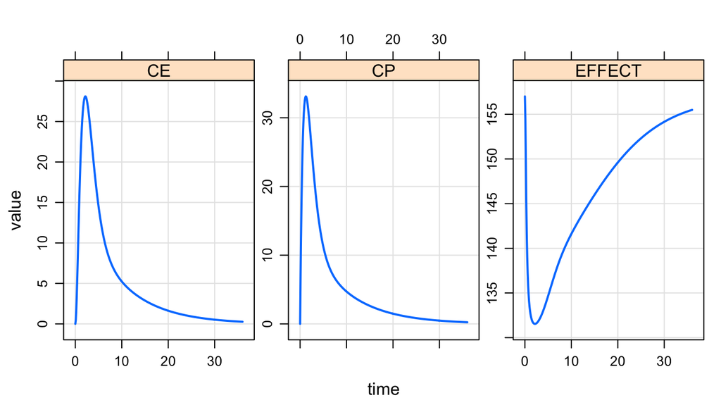

```r
plot(out)
```

Simulate steady state PK/PD under Q12 hour dosing

```r
out <- mod %>% ev(amt=200,ss=1,ii=12,addl=10)%>%
  mrgsim(Req="CP,CE,EFFECT", end=168)
```

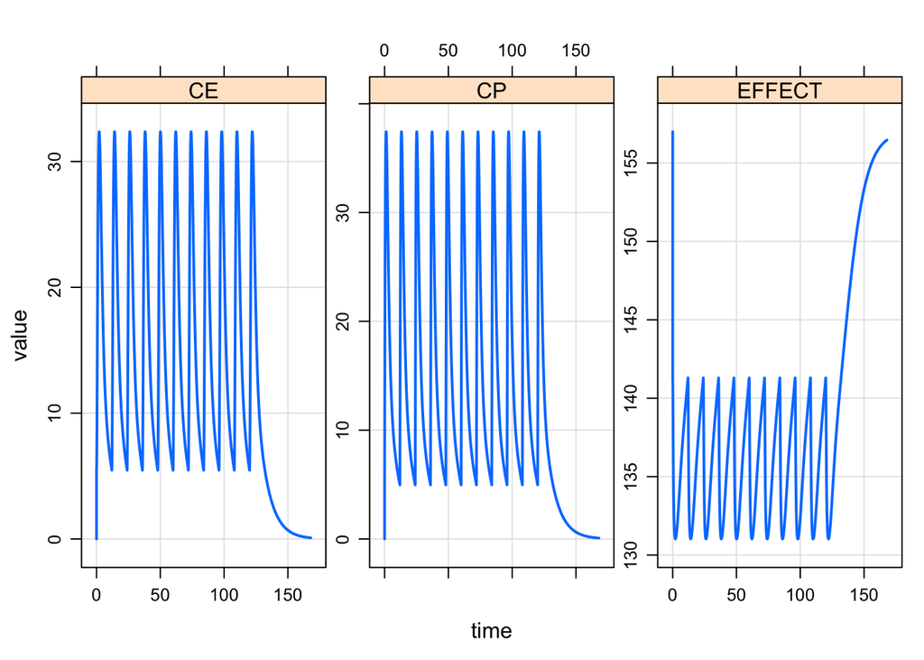

```r
plot(out)
```

# Population PK model with covariates and `IOV`

About this control stream

- `IOV` is declared as double precision variable that is set to either `ETA(4)` or `ETA(5)`
- We need to make sure that $\omega^2_{4}$ and $\omega^2_{5}$ are equal
- We assign different names to the first and second `$OMEGA` matrices so we can update them by name later
- We are tabling out some `ETAs` to look at them later as well; this is for demonstration purposes

```r
code <- '
$PARAM TVCL = 1.3, TVVC=28, TVKA=0.6, WT=70, OCC=1

$SET delta=0.1

$CMT GUT CENT

$MAIN

double IOV = EOC1;
if(OCC==2) IOV = EOC2;

double CLi = exp(log(TVCL) + 0.75*log(WT/70) + ECL + IOV);
double VCi = exp(log(TVVC) + EVC);
double KAi = exp(log(TVKA) + EKA);

$OMEGA
@name IIV @labels ECL EVC EKA
0 0 0
$OMEGA @name IOV @labels EOC1 EOC2
0 0

$SIGMA 0

$ODE
dxdt_GUT = -KAi*GUT;
dxdt_CENT = KAi*GUT - (CLi/VCi)*CENT;

$TABLE
double CP = CENT/VCi;
double ETA1 = ETA(1);
double ETA2 = ETA(2);

$CAPTURE IOV CP ETA1 ETA2
'
```

```r
mod <- mread("gallery4", tempdir(), code)
```

Set up dosing events; occasion 2 is the second dose

```r
dose <- ev(amt=300,OCC=1) + ev(amt=300,time=48,OCC=2)
dose
```

```
. Events:
.   time cmt amt OCC evid
. 1    0   1 300   1    1
. 2   48   1 300   2    1
```

ETAs are all zeros per the model specification code

```r
out <- mod %>% ev(dose) %>% mrgsim(end=120, nid=5)
```

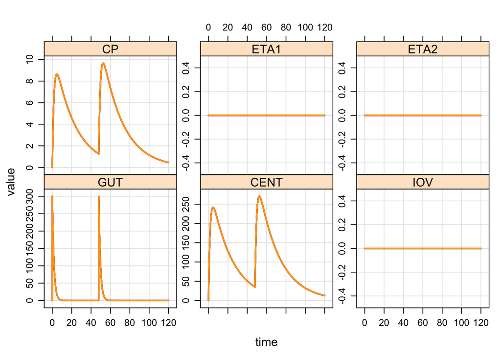

```r
plot(out)
```

Update `$OMEGA`

```r
mod <- mod %>% omat(IIV=cmat(0.1, 0.45, 0.3, 0,0,0), IOV=dmat(0.5,0.5))
```

And check the result

```r
revar(mod)
```

```
. $omega
. $IIV
.             [,1]       [,2] [,3]
. ECL:  0.10000000 0.07794229    0
. EVC:  0.07794229 0.30000000    0
. EKA:  0.00000000 0.00000000    0
.
. $IOV
.        [,1] [,2]
. EOC1:   0.5  0.0
. EOC2:   0.0  0.5
.
.
. $sigma
. $...
.     [,1]
. 1:     0
```

Simulate and plot

```r
out <- mod %>% ev(dose) %>% mrgsim(end=120,nid=5,seed=9765)
```

ETAs

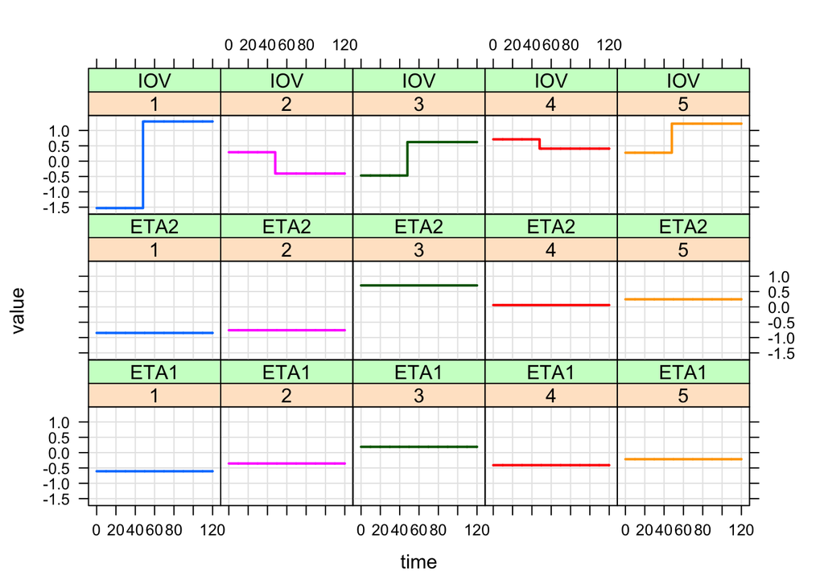

```r
plot(out,ETA1+ETA2+IOV~time|factor(ID),scales="same", layout=c(5,3))
```

PK

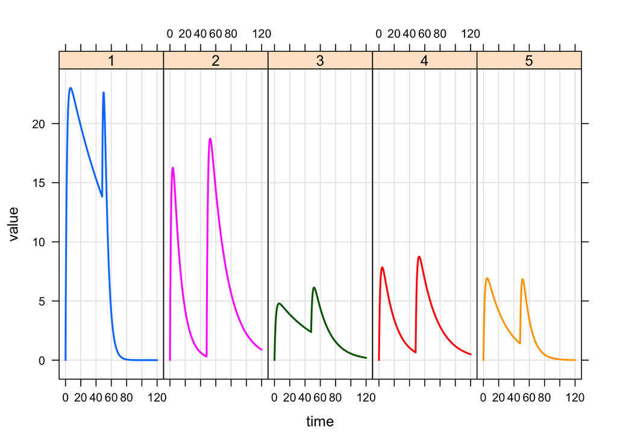

```r
plot(out,CP~time|factor(ID),scales="same", layout=c(5,1))
```

Just look at WT with no IIV/IOV

```r
mod <- mod %>% drop.re
```

```r
data <- expand.ev(amt=300,ii=12, addl=19,WT=seq(40,140,20))
```

```r
out <- mod %>% data_set(data) %>% Req(CP) %>% mrgsim(end=240, carry.out="WT")
```

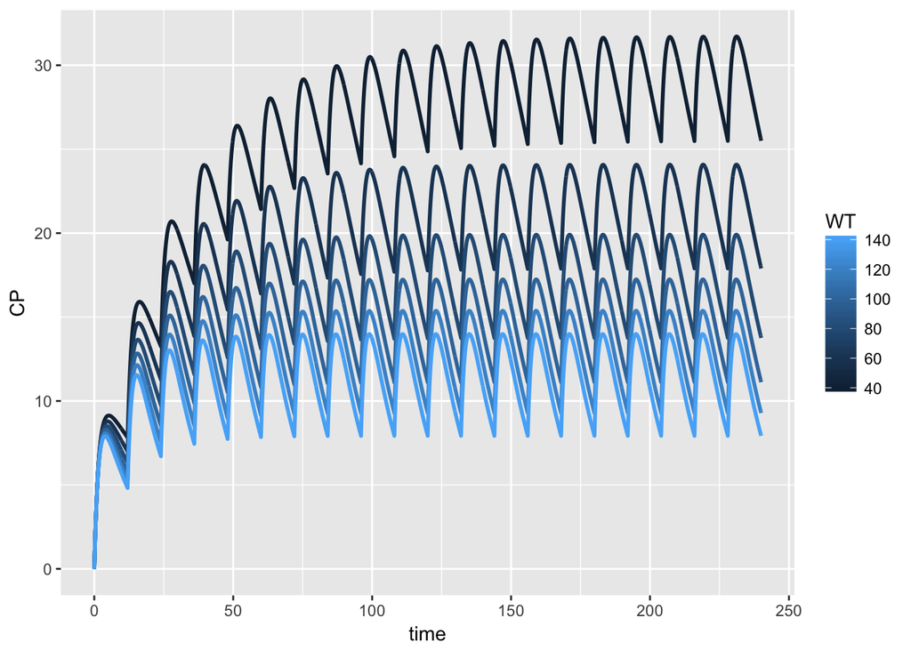

```r
out %>%
  as.tbl %>%
  ggplot(data=., aes(x=time, y=CP,col=WT,group=ID)) +
  geom_line(lwd=1)
```

Cmin versus weight

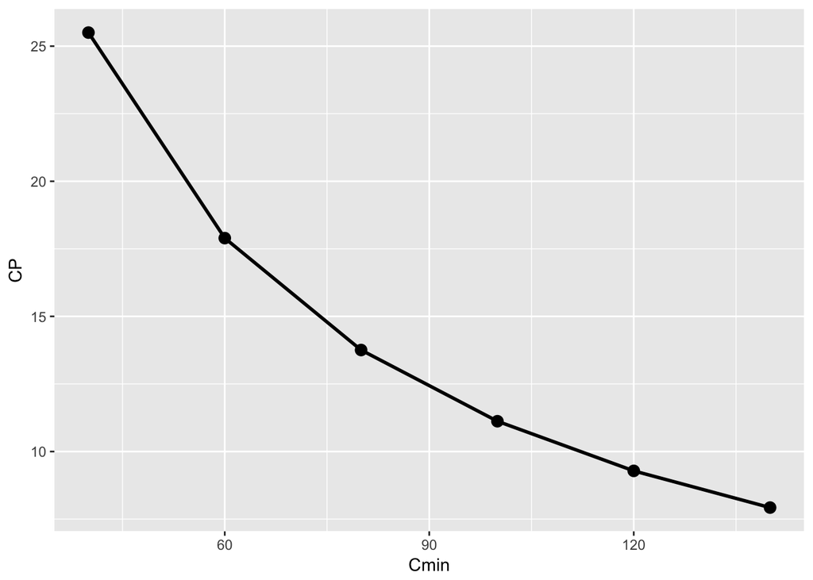

```r
out %>% subset(time==240) %>%
  ggplot(data=.,aes(x=WT,y=CP)) +
  geom_line(lwd=1) + geom_point(size=3) + xlab("Cmin")
```

# PK with dialysis sessions 3 times per week

About this control stream

- `GUT` and `CENT` are regular compartment; we have to provide a differential equation for each
- `DIAL` is a compartment that only holds a value; `dxdt_DIAL` will automatically be set to `0`
- `CLadd` is the additional drug clearance while on dialysis

```r
code <- '
$PARAM CL=0.7, VC=16, KA=1.8, CLadd = 2.1

$CMT GUT CENT

$VCMT DIAL

$ODE
dxdt_GUT = -KA*GUT;

dxdt_CENT = KA*GUT -  (CL + CLadd*DIAL)*CENT/VC;

$TABLE double CP = CENT/VC;

$CAPTURE CP
'
```

```r
mod <- mread("dialysis", tempdir(), code) %>% update(end=336, delta=0.25)
```

**Data assembly for doses and dialysis sessions**

```r
doses <- expand.ev(amt=300, ii=24, addl=13)
```

MWF dialysis sessions

```r
mon <- expand.ev(time=0,ii=7*24,addl=2,cmt=3,evid=8,amt=1)
wed <- mon %>% mutate(time=2*24)
fri <- wed %>% mutate(time=4*24)
```

Dialysis starts 8 hours after the AM dose

```r
dial_start <- bind_rows(mon,wed,fri) %>% mutate(time=time+8)
```

Dialysis lasts 3 hours

```r
dial_end <- dial_start %>% mutate(time = time+3, amt=0)
```

Doses and dialysis

```r
events <- bind_rows(dial_start,dial_end,doses) %>% arrange(time) %>% as.data.frame %>% as.ev

events
```

```
. Events:
.   ID time  ii addl cmt evid amt
. 1  1    0  24   13   1    1 300
. 2  1    8 168    2   3    8   1
. 3  1   11 168    2   3    8   0
. 4  1   56 168    2   3    8   1
. 5  1   59 168    2   3    8   0
. 6  1  104 168    2   3    8   1
. 7  1  107 168    2   3    8   0
```

**Simulate**

```r
out <- mod %>% ev(events) %>%  obsonly %>% mrgsim
```

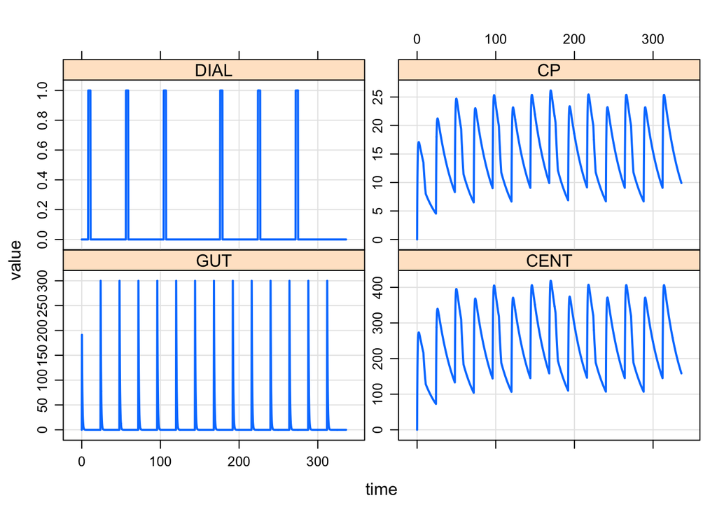

```r
plot(out)
```

PK plot with dialysis sessions marked in red

```
. Joining, by = c("ID", "time")
```

```
. Warning: Removed 1 rows containing missing values (geom_path).
```

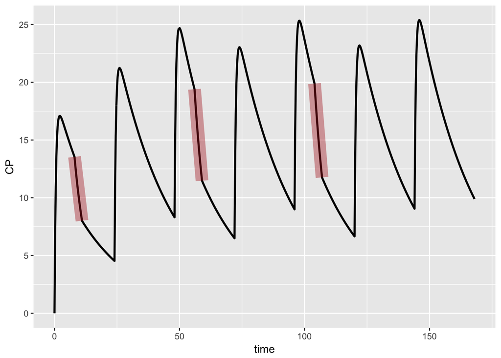

```r
out %>% as.tbl %>% filter(time <=7*24) %>%
  ggplot(data=., aes(x=time, y=CP)) + geom_line(lwd=1) +
  geom_path(data=dial,col="firebrick", lwd=6, alpha=0.4)
```

# References

J. Gabrielsson and D. Weiner. Pharmacokinetic and Pharmacodynamic Data Analysis: Concepts and Applications, Fourth Edition. Taylor & Francis, 2007.

```
. R version 3.3.2 (2016-10-31)
. Platform: x86_64-apple-darwin13.4.0 (64-bit)
. Running under: OS X Mavericks 10.9.5
.
. locale:
. [1] en_US.UTF-8/en_US.UTF-8/en_US.UTF-8/C/en_US.UTF-8/en_US.UTF-8
.
. attached base packages:
. [1] stats     grDevices utils     datasets  graphics  methods   base
.
. other attached packages:
.  [1] tidyr_0.6.1          lattice_0.20-34      magrittr_1.5
.  [4] dplyr_0.5.0          minqa_1.2.4          ggplot2_2.2.1
.  [7] knitr_1.15.1         mrgsolve_0.7.10.9005 rmarkdown_1.3
. [10] blogdown_0.0.22
.
. loaded via a namespace (and not attached):
.  [1] Rcpp_0.12.9               rstudioapi_0.6
.  [3] servr_0.5                 munsell_0.4.3
.  [5] colorspace_1.3-2          R6_2.2.0
.  [7] RcppArmadillo_0.7.700.0.0 plyr_1.8.4
.  [9] stringr_1.2.0             tools_3.3.2
. [11] grid_3.3.2                gtable_0.2.0
. [13] DBI_0.5-1                 htmltools_0.3.5
. [15] yaml_2.1.14               lazyeval_0.2.0
. [17] rprojroot_1.2             digest_0.6.12
. [19] assertthat_0.1            tibble_1.2
. [21] bookdown_0.3.9            rsconnect_0.7
. [23] evaluate_0.10             mime_0.5
. [25] labeling_0.3              stringi_1.1.2
. [27] scales_0.4.1              backports_1.0.5
. [29] httpuv_1.3.3
```

```r
date()
```

```
. [1] "Thu Feb 23 00:37:21 2017"
```